# Final data project: Facebook trolling

## Introduction

The first step was to collect data through a survey on Facebook trolling. I got a total of 57 responses.

```
## # A tibble: 6 x 27
##   StartDate  EndDate  Status  IPAddress Progress `Duration (in s… Finished
##   <chr>      <chr>    <chr>   <chr>     <chr>    <chr>            <chr>
## 1 Start Date End Date Respon… IP Addre… Progress Duration (in se… Finished
## 2 "{\"Impor… "{\"Imp… "{\"Im… "{\"Impo… "{\"Imp… "{\"ImportId\":… "{\"Imp…
## 3 2018-03-3… 2018-03… Survey… <NA>      100      6                True
## 4 2018-03-3… 2018-03… IP Add… 185.69.1… 100      3                True
## 5 2018-03-3… 2018-03… IP Add… 212.236.… 100      90               True
## 6 2018-03-3… 2018-03… IP Add… 78.92.3.… 100      39               True
## # ... with 20 more variables: RecordedDate <chr>, ResponseId <chr>,
## #   RecipientLastName <chr>, RecipientFirstName <chr>,
## #   RecipientEmail <chr>, ExternalReference <chr>, LocationLatitude <chr>,
## #   LocationLongitude <chr>, DistributionChannel <chr>,
## #   UserLanguage <chr>, Q1 <chr>, Q2 <chr>, Q2_3_TEXT <chr>, Q10 <chr>,
## #   Q3 <chr>, Q5 <chr>, Q6 <chr>, Q7 <chr>, Q7_3_TEXT <chr>, Q9 <chr>
```

```
## # A tibble: 6 x 28
##   id    StartDate   EndDate   Status  IPAddress Progress `Duration (in se…
##   <chr> <chr>       <chr>     <chr>   <chr>     <chr>    <chr>
## 1 1     2018-03-30… 2018-03-… Survey… <NA>      100      6
## 2 2     2018-03-30… 2018-03-… IP Add… 185.69.1… 100      3
## 3 3     2018-03-30… 2018-03-… IP Add… 212.236.… 100      90
## 4 4     2018-03-30… 2018-03-… IP Add… 78.92.3.… 100      39
## 5 5     2018-03-30… 2018-03-… IP Add… 79.68.16… 100      98
## 6 6     2018-03-30… 2018-03-… IP Add… 14.139.1… 100      55
## # ... with 21 more variables: Finished <chr>, RecordedDate <chr>,
## #   ResponseId <chr>, RecipientLastName <chr>, RecipientFirstName <chr>,
## #   RecipientEmail <chr>, ExternalReference <chr>, LocationLatitude <chr>,
## #   LocationLongitude <chr>, DistributionChannel <chr>,
## #   UserLanguage <chr>, Q1 <chr>, Q2 <chr>, Q2_3_TEXT <chr>, Q10 <chr>,
## #   Q3 <chr>, Q5 <chr>, Q6 <chr>, Q7 <chr>, Q7_3_TEXT <chr>, Q9 <chr>
```

## 2. Data Columns

Let’s now see what the columns of our data set are. Note that the first 17 columns are metadata that Qualtrics inserted.

```r
colnames(data)
```

```
##  [1] "id"                    "StartDate"
##  [3] "EndDate"               "Status"
##  [5] "IPAddress"             "Progress"
##  [7] "Duration (in seconds)" "Finished"
##  [9] "RecordedDate"          "ResponseId"
## [11] "RecipientLastName"     "RecipientFirstName"
## [13] "RecipientEmail"        "ExternalReference"
## [15] "LocationLatitude"      "LocationLongitude"
## [17] "DistributionChannel"   "UserLanguage"
## [19] "Q1"                    "Q2"
## [21] "Q2_3_TEXT"             "Q10"
## [23] "Q3"                    "Q5"
## [25] "Q6"                    "Q7"
## [27] "Q7_3_TEXT"             "Q9"
```

## Facebook Analysis

See how many people have experienced trolling

```r
data %>% group_by(Q1) %>% count
```

```
## # A tibble: 2 x 2
## # Groups:   Q1 [2]
##   Q1        n
##   <chr> <int>
## 1 No       20
## 2 Yes      37
```

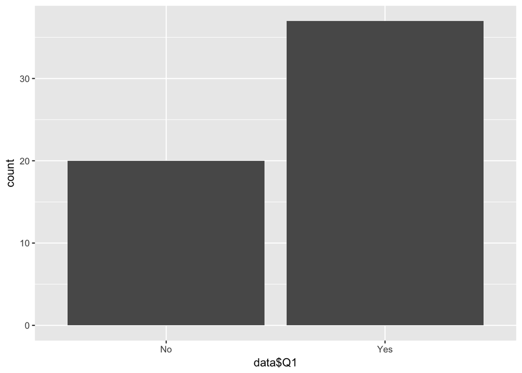

```r
ggplot(data, aes(data$Q1)) + geom_bar()
```

```r
# create Q1_num
data <- data %>% mutate(Q1_num=as.numeric(Q1))

# show unsuccessful conversions
invalid_ids <-  data %>% filter(is.na(Q1_num)) %>% pull(id)
data %>% filter(is.na(Q1_num)) %>% select(id,Q1,Q1_num)
```

```
## # A tibble: 57 x 3
##    id    Q1    Q1_num
##    <chr> <chr>  <dbl>
##  1 1     No        NA
##  2 2     No        NA
##  3 3     Yes       NA
##  4 4     Yes       NA
##  5 5     Yes       NA
##  6 6     Yes       NA
##  7 7     No        NA
##  8 8     Yes       NA
##  9 9     No        NA
## 10 10    No        NA
## # ... with 47 more rows
```

```r
data %>% group_by(Q2) %>% count
```

```
## # A tibble: 3 x 2
## # Groups:   Q2 [3]
##   Q2                                                                     n
##   <chr>                                                              <int>
## 1 Personally directed remark                                            13
## 2 Remark on a certain community or group that you belong to (it cou…    20
## 3 <NA>                                                                  24
```

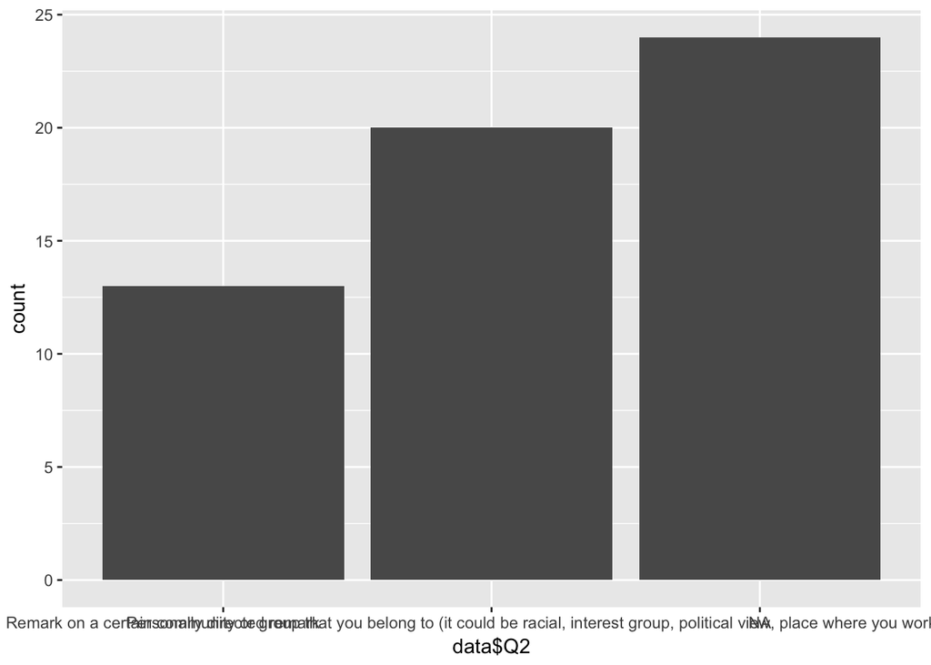

```r
ggplot(data, aes(data$Q2)) + geom_bar()
```

```r
data %>% group_by(Q3) %>% count
```

```
## # A tibble: 6 x 2
## # Groups:   Q3 [6]
##   Q3                       n
##   <chr>                <int>
## 1 1-3 times a day         13
## 2 10-12 times a day       15
## 3 I don't keep a track     2
## 4 Once a day               1
## 5 Once a week              2
## 6 <NA>                    24
```

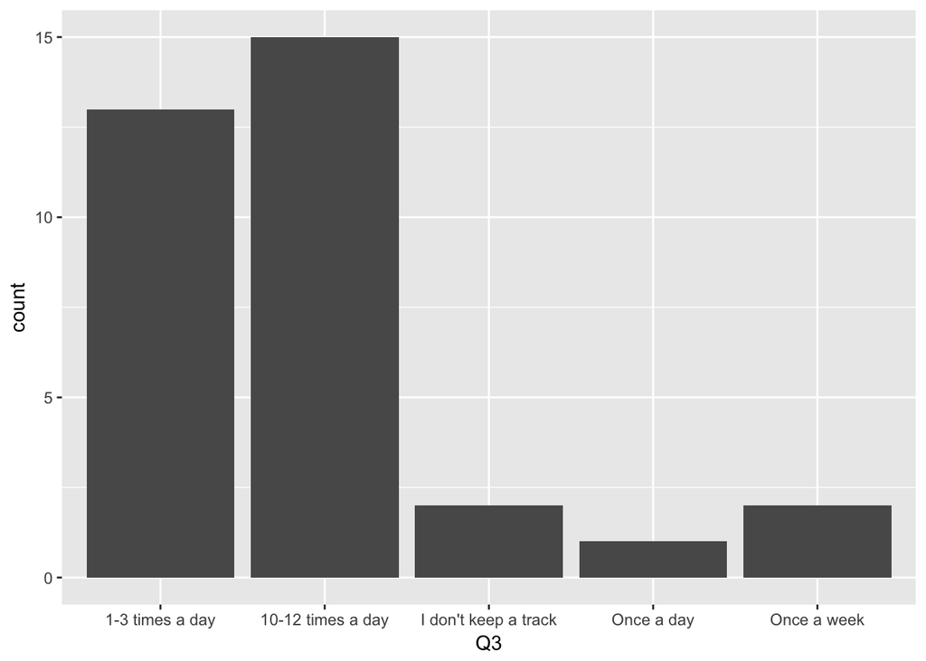

```r
data %>% filter(Q3 != "") %>% ggplot(aes(Q3)) + geom_bar()
```

```r
data %>% drop_na()
```

```
## # A tibble: 0 x 29
## # ... with 29 variables: id <chr>, StartDate <chr>, EndDate <chr>,
## #   Status <chr>, IPAddress <chr>, Progress <chr>, `Duration (in
## #   seconds)` <chr>, Finished <chr>, RecordedDate <chr>, ResponseId <chr>,
## #   RecipientLastName <chr>, RecipientFirstName <chr>,
## #   RecipientEmail <chr>, ExternalReference <chr>, LocationLatitude <chr>,
## #   LocationLongitude <chr>, DistributionChannel <chr>,
## #   UserLanguage <chr>, Q1 <chr>, Q2 <chr>, Q2_3_TEXT <chr>, Q10 <chr>,
## #   Q3 <chr>, Q5 <chr>, Q6 <chr>, Q7 <chr>, Q7_3_TEXT <chr>, Q9 <chr>,
## #   Q1_num <dbl>
```

```r
data %>% group_by(Q10) %>% count
```

```
## # A tibble: 4 x 2
## # Groups:   Q10 [4]
##   Q10       n
##   <chr> <int>
## 1 Maybe     4
## 2 No       18
## 3 Yes      11
## 4 <NA>     24
```

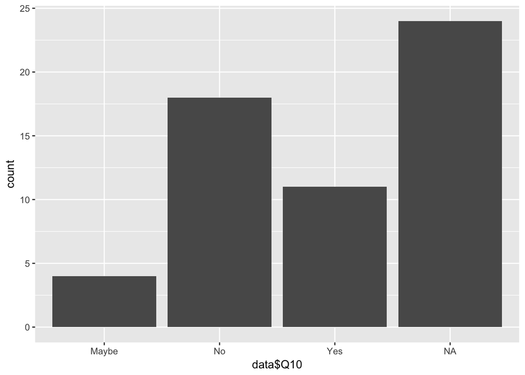

```r
ggplot(data, aes(data$Q10)) + geom_bar()
```

```r
heatmap_1 <- matrix(c(14,10,26,12,8,17),ncol=3,byrow=TRUE)
colnames(heatmap_1) <- c("PR","CR", "Report")
rownames(heatmap_1) <- c("Male","Female")
heatmap_1 <- as.table(heatmap_1)
heatmap_1
```

```
##        PR CR Report
## Male   14 10     26
## Female 12  8     17
```

```r
heat_matrix <- data.matrix(heatmap_1)
```

## Heatmap

Here I was trying to create a Heatmap to see patterns between Male-Female and who reported more than the other, and if male or female faced personal remark/community remark more than the other person.

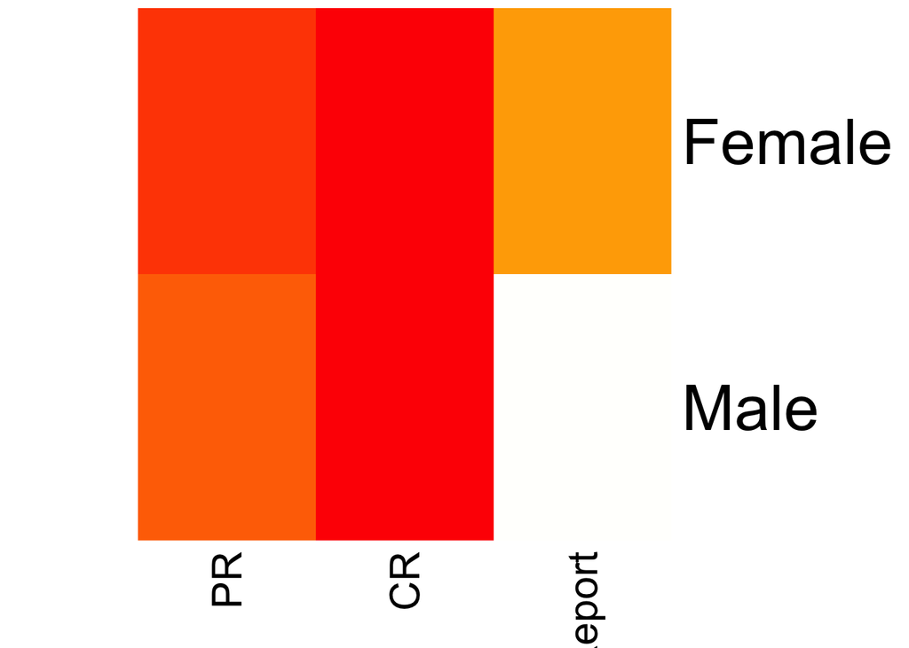

```r
malefemale_heatmap <- heatmap(heat_matrix, Rowv=NA, Colv=NA, col = heat.colors(256), scale="none", margins=c(5,5))
```

## Total time

I was interested in doing some kind of t test to see which group Male or Female spends more time on Facebook. To do that, I converted new column which stores average number of times people login to their Fb account. I created another column which has total time spent by people each time they logged in. I then multipiled the two to get the total time spent with male/female ratio. Then, I ran t test.

```r
data <- data %>%
  mutate(Q3_num = case_when(Q3 == "10-12 times a day" ~ "11",
                            Q3 == "Once a day" ~ "1",
                            Q3 == "1-3 times a day" ~ "1.5",
                            Q3 == "Once a week" ~ "0.14",
                            Q3 == "I don't keep a track" ~ "0",
                            Q3 == "" ~ "0",
                            Q3 == "NA" ~ "0"))
data <- data %>%
  mutate(Q5_num = case_when(Q5 == "1-5 minutes (Quickly checking notifications)" ~ "2.5",
                            Q5 == "An hour" ~ "60",
                            Q5 == "1-3 times a day" ~ "1.5",
                            Q5 == "10-15 minutes" ~ "12.5",
                            Q5 == "It really depends on the day" ~ "0",
                            Q5 == "I have no idea" ~ "0",
                            Q5 == "" ~ "0",
                            Q5 == "NA" ~ "0"))
```

# Descriptive statistics for how many times Fb was accessed in a day

```r
data <- data %>% drop_na(Q3_num) %>% mutate(Q3_num=as.numeric(Q3_num))
data <- data %>% drop_na(Q5_num) %>% mutate(Q5_num=as.numeric(Q5_num))
data <- data %>% mutate(total_time = Q3_num * Q5_num)
```

```r
data %>% summarise(Q3_mean = mean(Q3_num),
Q3_median = median(Q3_num),
Q3_min = min(Q3_num),
Q3_max = max(Q3_num),
Q3_total = n(),
Q3_sd = sd(Q3_num))
```

```
## # A tibble: 1 x 6
##   Q3_mean Q3_median Q3_min Q3_max Q3_total Q3_sd
##     <dbl>     <dbl>  <dbl>  <dbl>    <int> <dbl>
## 1    5.90      1.50      0   11.0       31  5.04
```

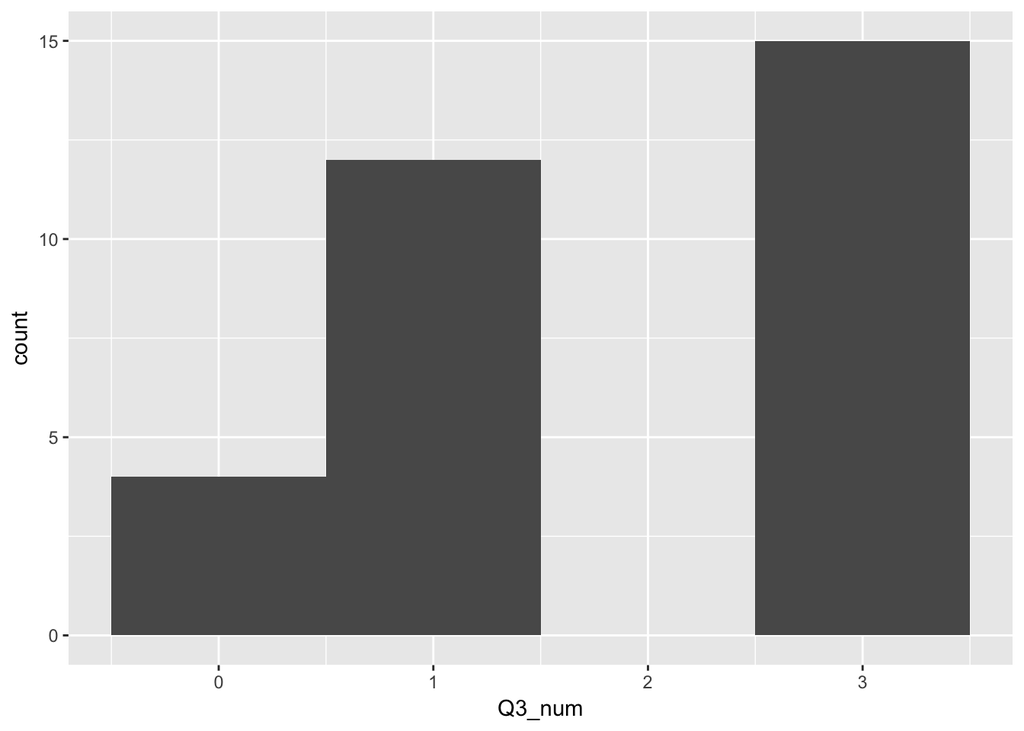

```r
ggplot(data %>% transmute(Q3_num=sqrt(Q3_num)), aes(Q3_num)) + geom_histogram(binwidth=1) #coord_cartesian(xlim=c(0,3100),ylim=c(0,15))
```

For those who only identify themselves as Females

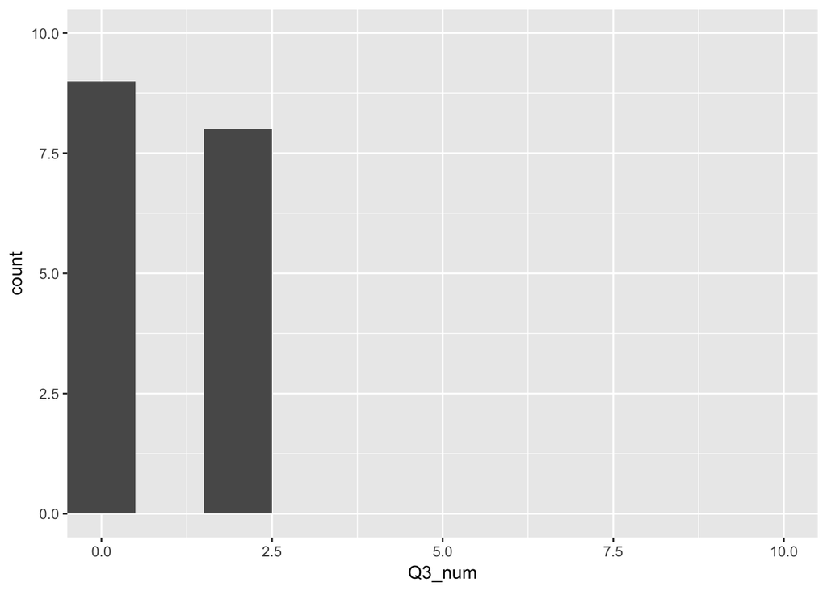

```r
females <- data %>% filter(Q7 == "Female") %>% mutate(Q3_num=log(Q3_num))
ggplot(females, aes(Q3_num)) + geom_histogram(binwidth=1)+ coord_cartesian(xlim=c(0,
10),ylim=c(0,10))
```

For those who only identify themselves as Mmales

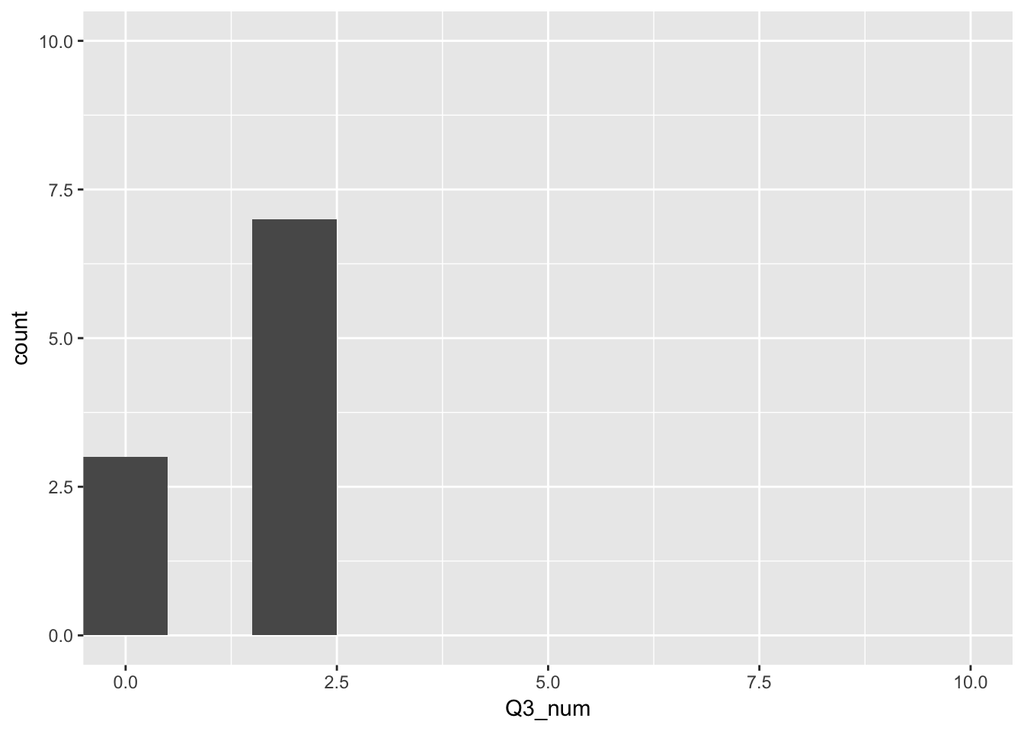

```r
males <- data %>% filter(Q7 == "Male") %>% mutate(Q3_num=log(Q3_num))
ggplot(males, aes(Q3_num)) + geom_histogram(binwidth=1)+ coord_cartesian(xlim=c(0,
10),ylim=c(0,10))
```

# Descriptive statistics for how much time was spent on Fb each time that a person logged in (time in minutes)

```r
data %>% summarise(Q5_mean = mean(Q5_num),
Q5_median = median(Q5_num),
Q5_min = min(Q5_num),
Q5_max = max(Q5_num),
Q5_total = n(),
Q5_sd = sd(Q5_num))
```

```
## # A tibble: 1 x 6
##   Q5_mean Q5_median Q5_min Q5_max Q5_total Q5_sd
##     <dbl>     <dbl>  <dbl>  <dbl>    <int> <dbl>
## 1    14.9      2.50      0   60.0       31  22.9
```

[figure not shown]

```r
ggplot(data %>% transmute(Q3_num=sqrt(Q3_num)), aes(Q3_num)) + geom_histogram(binwidth=1) #coord_cartesian(xlim=c(0,3100),ylim=c(0,15))
```

For those who qualify themselves as females

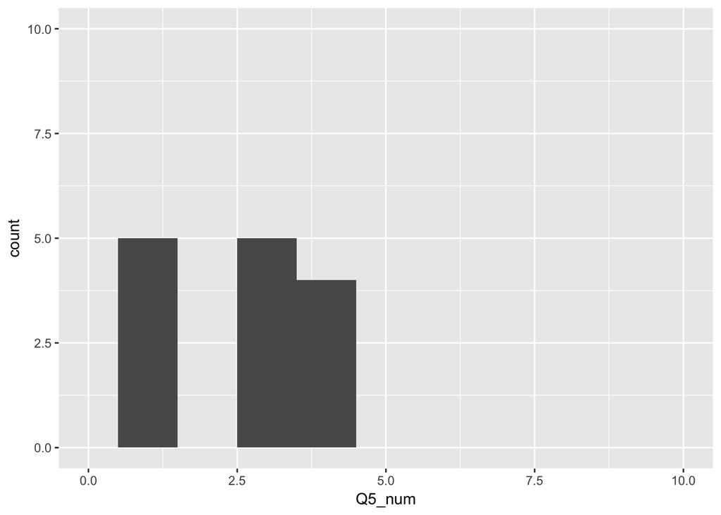

```r
females <- data %>% filter(Q7 == "Female") %>% mutate(Q5_num=log(Q5_num))
ggplot(females, aes(Q5_num)) + geom_histogram(binwidth=1)+ coord_cartesian(xlim=c(0,
10),ylim=c(0,10))
```

For those who qualify themselves as males

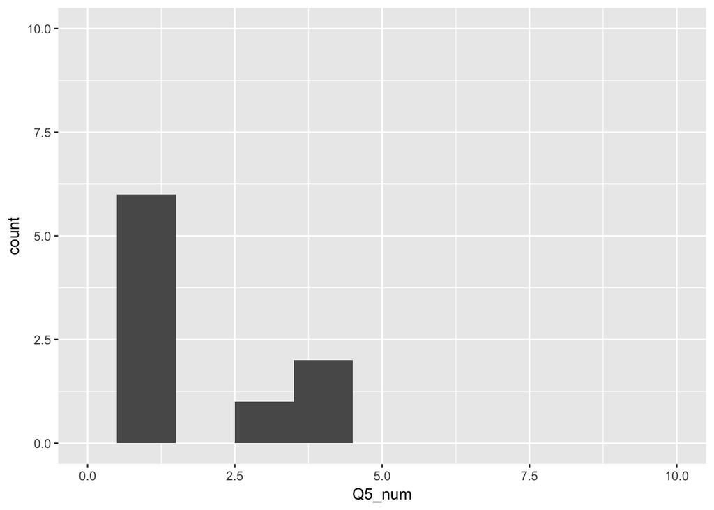

```r
males <- data %>% filter(Q7 == "Male") %>% mutate(Q5_num=log(Q5_num))
ggplot(males, aes(Q5_num)) + geom_histogram(binwidth=1)+ coord_cartesian(xlim=c(0,
10),ylim=c(0,10))
```

# Descriptive statistics for how much time was spent on Fb

```r
data %>% summarise(t_mean = mean(total_time),
t_median = median(total_time),
t_min = min(total_time),
t_max = max(total_time),
t_total = n(),
t_sd = sd(total_time))
```

```
## # A tibble: 1 x 6
##   t_mean t_median t_min t_max t_total  t_sd
##    <dbl>    <dbl> <dbl> <dbl>   <int> <dbl>
## 1    112     18.8     0   660      31   219
```

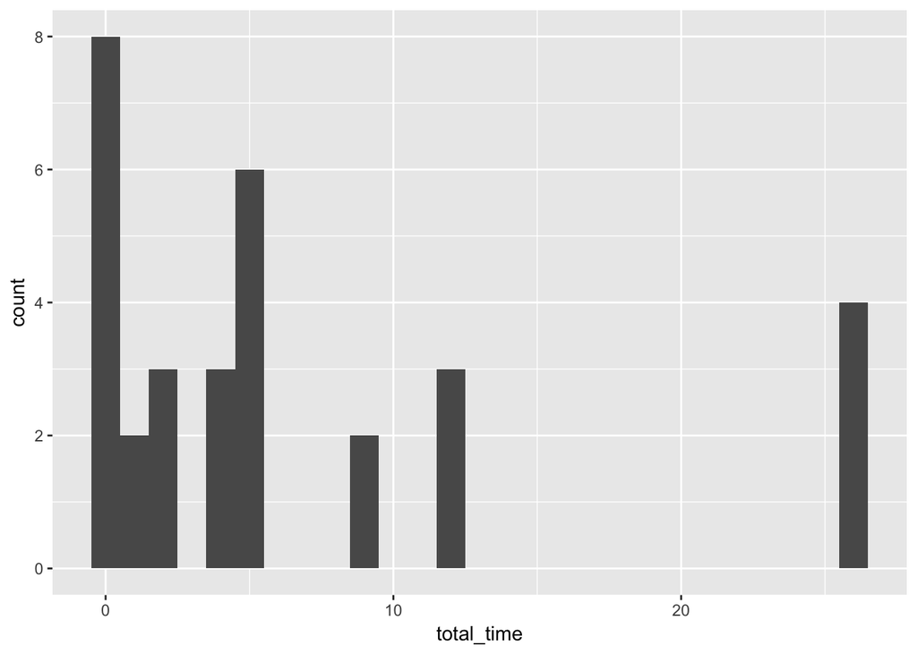

```r
ggplot(data %>% transmute(total_time=sqrt(total_time)), aes(total_time)) + geom_histogram(binwidth=1) #coord_cartesian(xlim=c(0,100),ylim=c(0,20))
```

Now running t test to see who uses more facebook between males and females

```r
female <- data %>% filter(Q7 == "Female")
male <- data %>% filter(Q7 == "Male")
male_tt <- male %>% pull(total_time)
female_tt <- female %>% pull(total_time)
t.test(male_tt,female_tt,var.equal=TRUE)
```

```
##
##  Two Sample t-test
##
## data:  male_tt and female_tt
## t = -0.04528, df = 29, p-value = 0.9642
## alternative hypothesis: true difference in means is not equal to 0
## 95 percent confidence interval:
##  -169.1646  161.8364
## sample estimates:
## mean of x mean of y
##  109.6692  113.3333
```

```r
megaplot <- data %>% select(Q7,Q3_num, Q5_num, total_time)
```

```r
print(megaplot)
```

```
## # A tibble: 31 x 4
##    Q7     Q3_num Q5_num total_time
##    <chr>   <dbl>  <dbl>      <dbl>
##  1 Female 11.0     2.50     27.5
##  2 Female 11.0    60.0     660
##  3 Female 11.0    12.5     138
##  4 Male    1.00    0         0
##  5 Male   11.0     0         0
##  6 Male    0.140   2.50      0.350
##  7 Male    0       0         0
##  8 Male   11.0    60.0     660
##  9 Female  1.50    0         0
## 10 Female  1.50   60.0      90.0
## # ... with 21 more rows
```

```r
library(GGally)
```

[figure not shown]

```r
ggparcoord(megaplot, columns = 1:4, groupColumn = 'Q7', scale = 'globalminmax')
```

```r
# group by combinations and count
#megaplot %>% group_by(Q7) %>% count()

# set an id string that denotes the value combination
megaplot %>% mutate(id = factor(paste(Q3_num, Q5_num, total_time, Q7, sep = '-')))
```

```
## # A tibble: 31 x 5
##    Q7     Q3_num Q5_num total_time id
##    <chr>   <dbl>  <dbl>      <dbl> <fct>
##  1 Female 11.0     2.50     27.5   11-2.5-27.5-Female
##  2 Female 11.0    60.0     660     11-60-660-Female
##  3 Female 11.0    12.5     138     11-12.5-137.5-Female
##  4 Male    1.00    0         0     1-0-0-Male
##  5 Male   11.0     0         0     11-0-0-Male
##  6 Male    0.140   2.50      0.350 0.14-2.5-0.35-Male
##  7 Male    0       0         0     0-0-0-Male
##  8 Male   11.0    60.0     660     11-60-660-Male
##  9 Female  1.50    0         0     1.5-0-0-Female
## 10 Female  1.50   60.0      90.0   1.5-60-90-Female
## # ... with 21 more rows
```

```r
megaplot2 <- megaplot %>% mutate(id = factor(paste(Q3_num, Q5_num, total_time, Q7, sep = '-')))
```

```r
head(megaplot2, n=31)
```

```
## # A tibble: 31 x 5
##    Q7     Q3_num Q5_num total_time id
##    <chr>   <dbl>  <dbl>      <dbl> <fct>
##  1 Female 11.0     2.50     27.5   11-2.5-27.5-Female
##  2 Female 11.0    60.0     660     11-60-660-Female
##  3 Female 11.0    12.5     138     11-12.5-137.5-Female
##  4 Male    1.00    0         0     1-0-0-Male
##  5 Male   11.0     0         0     11-0-0-Male
##  6 Male    0.140   2.50      0.350 0.14-2.5-0.35-Male
##  7 Male    0       0         0     0-0-0-Male
##  8 Male   11.0    60.0     660     11-60-660-Male
##  9 Female  1.50    0         0     1.5-0-0-Female
## 10 Female  1.50   60.0      90.0   1.5-60-90-Female
## # ... with 21 more rows
```

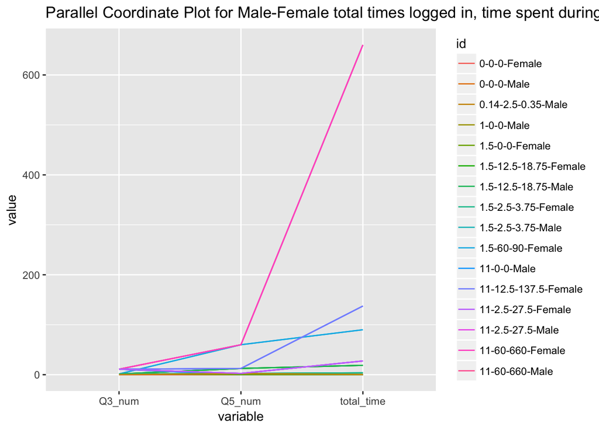

```r
library(GGally)

ggparcoord(megaplot2, columns = 2:4, groupColumn = 'id', scale = 'globalminmax', missing = 'exclude', title = "Parallel Coordinate Plot for Male-Female total times logged in, time spent during each logged session and total time ")
```

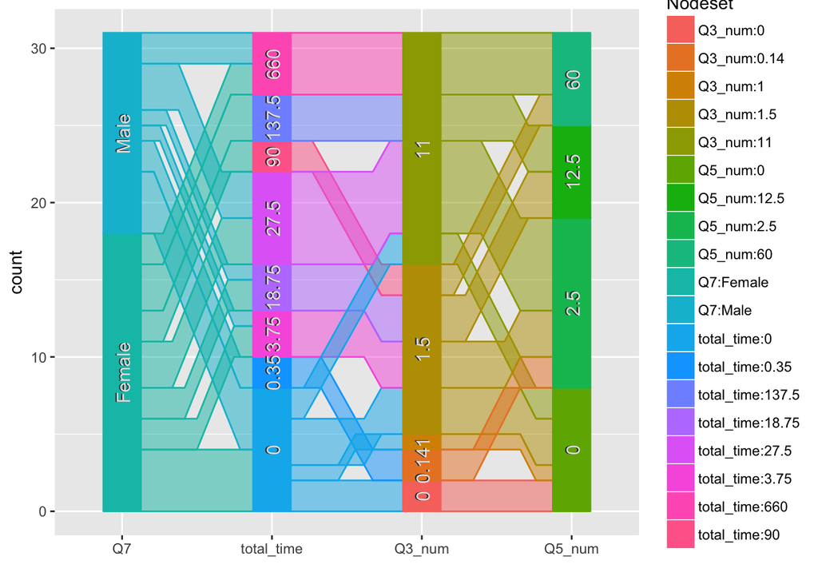

```r
mp3<- as.data.frame(megaplot2)
library(ggparallel)
ggparallel(list('Q7','total_time', 'Q3_num', 'Q5_num'), mp3, order = 0)
```

This is the end of results—————–